# Swearing online: Exploring dimensions of variability in born-digital data - Part 2: Data Processing and Usage Statistics

Martin Schweinberger

2026-03-15

# Introduction

This notebook documents the second stage of the analysis of swear words in the Australian (AU), British (GB), and American (US) Twitterspheres. Building on the cleaned KWIC data produced in Part 1, it covers:

# Preparation

## Install packages

Set `eval = TRUE` on first use; revert to `eval = FALSE` once packages are installed.

```r
install.packages(c(
  "dplyr",       # data manipulation
  "here",        # reproducible file paths
  "stringr",     # string operations
  "quanteda",    # corpus tools
  "tidytext",    # tidy text utilities (incl. reorder_within)
  "sentimentr",  # sentiment analysis (used in later notebooks)
  "writexl",     # Excel export
  "ggplot2",     # visualisation
  "Hmisc",       # miscellaneous stats utilities
  "cfa",         # Configuration Frequency Analysis
  "countrycode", # country code conversion
  "ggimage",     # image-based ggplot2 extensions
  "forcats",     # factor reordering helpers
  "devtools"     # install from GitHub
))
devtools::install_github("rensa/ggflags")  # flag emoji geoms for ggplot2
```

## Activate packages

```r
library(dplyr)
library(here)
library(stringr)
library(tidytext)
library(quanteda)
library(sentimentr)
library(writexl)
library(ggplot2)
library(Hmisc)
library(cfa)
library(countrycode)
library(ggflags)
library(forcats)
```

# Load Data

Load the full tweet dataset (for word counts) and the cleaned KWIC results (for swear word instances) produced in Part 1.

```r
twdat  <- readRDS(file = here("data", "twdat.rda"))
kwicdf <- readRDS(file = here("tables", "kwicdf_clean.rda"))

str(twdat)
```

```
## tibble [2,729,037 × 41] (S3: tbl_df/tbl/data.frame)
##  $ tweet_id                    : num [1:2729037] 1.54e+18 1.54e+18 1.54e+18 1.54e+18 1.54e+18 ...
##  $ tweet_created_at            : chr [1:2729037] "2022-06-21T00:00:00.000Z" "2022-06-21T00:00:01.000Z" "2022-06-21T00:00:01.000Z" "2022-06-21T00:00:01.000Z" ...
##  $ tweet_retrieved_at          : chr [1:2729037] "2022-07-14T00:04:16+00:00" "2022-07-13T23:29:57+00:00" "2022-07-13T23:39:12+00:00" "2022-07-13T23:53:07+00:00" ...
##  $ conversation_id             : num [1:2729037] 1.54e+18 1.54e+18 1.54e+18 1.54e+18 1.54e+18 ...
##  $ retweeted_tweet_id          : logi [1:2729037] NA NA NA NA NA NA ...
##  $ quoted_tweet_id             : num [1:2729037] NA NA NA NA NA NA NA NA NA NA ...
##  $ replied_to_tweet_id         : num [1:2729037] NA NA 1.54e+18 NA NA ...
##  $ text                        : chr [1:2729037] "Tonight at 10PM EST\n\n@SocietyMovies \n@ImJustHereSoI18 \n@RXCafeTX \nand Matthew Pejkovic\n\nReview the lates"| __truncated__ "Did you know? \"In Zimbabwe, it is illegal for citizens to make offensive gestures at a passing car\" Yeah, wel"| __tr…
##  $ transformed_text            : chr [1:2729037] " Tonight  at  10PM  EST \n \n  \n  \n  \n and  Matthew  Pejkovic \n \n Review  the  latest  Disney  flop  and  "| __truncated__ " Did  you  know ?  \" In  Zimbabwe ,  it  is  illegal  for  citizens  to  make  offensive  gestures  at  a  pas"| __tr…
##  $ lang                        : chr [1:2729037] "en" "en" "en" "tl" ...
##  $ source                      : chr [1:2729037] "Twitter Web App" "Twitter Web App" "Twitter for Android" "Hobart GPO Clock" ...
##  $ possibly_sensitive          : int [1:2729037] 0 0 0 0 0 0 0 0 0 0 ...
##  $ reply_settings              : chr [1:2729037] "everyone" "everyone" "everyone" "everyone" ...
##  $ like_count                  : int [1:2729037] 4 0 0 0 5 115 1 13 0 0 ...
```

[output cut: 27 more lines]

```r
str(kwicdf)
```

```
## 'data.frame':    166516 obs. of  7 variables:
##  $ docname         : chr  "text100" "text100" "text105" "text118" ...
##  $ pre             : chr  "is rolled out. make a" "is rolled out. make a" "have a great list of" "men know they voted to" ...
##  $ keyword         : chr  "fucking" "fucking" "pedo" "fuck" ...
##  $ post            : chr  "decision and do it." "decision and do it." "groomers we can keep our" "brad pitt or oscar.🨂" ...
##  $ code            : chr  "au" "au" "au" "au" ...
##  $ lemma           : Named chr  "dildo" "dork" "dick" "dildo" ...
##   ..- attr(*, "names")= chr [1:166516] "\\bdildo(s|z)*\\b" "\\bdork(s|z)*\\b" "\\b[d][1!|ïíì][c¢©(][xk|<{(][(head)]*[zs]*\\b" "\\bdildo(s|z)*\\b" ...
##  $ keyword_original: chr  "fucking" "fucking" "pedo" "fuck" ...
```

# Vulgar Language Overview

## Figure 1: Raw frequency of each vulgar lemma (all countries combined)

This plot shows how often each lemma appears across the entire corpus, with percentage labels to indicate each lemma’s share of total vulgarity instances.

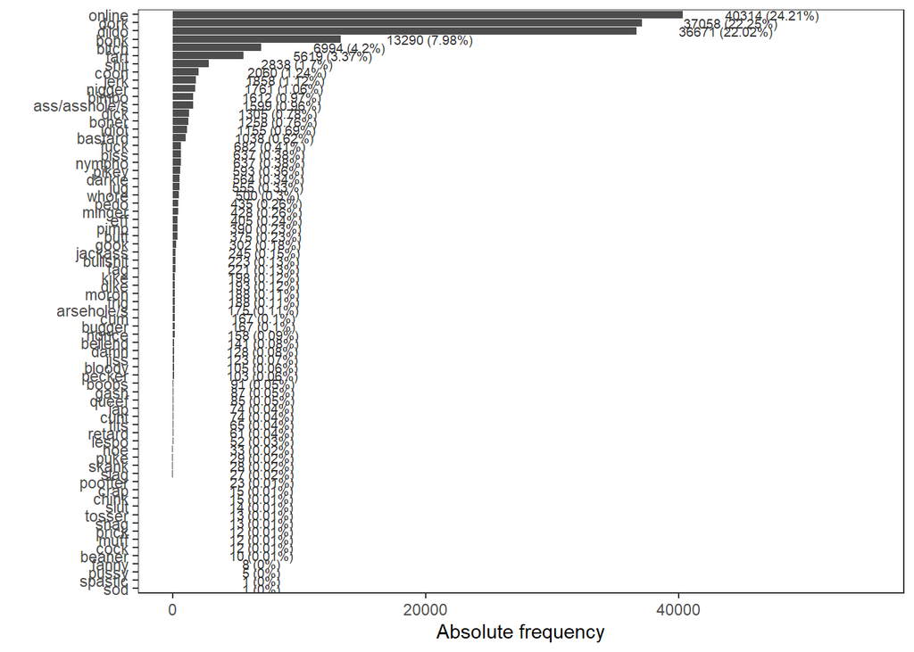

```r
kwicdf |>
  group_by(lemma) |>
  summarise(freq = n()) |>
  ungroup() |>
  mutate(
    total   = sum(freq),
    percent = round(freq / total * 100, 2)
  ) |>
  ggplot(aes(reorder(lemma, freq), freq)) +
  geom_bar(stat = "identity", fill = "gray30") +
  geom_text(
    aes(y = freq + 7000,
        label = paste0(freq, " (", percent, "%)")),
    size = 2.5, col = "gray20"
  ) +
  theme_bw() +
  labs(x = "", y = "Absolute frequency") +
  coord_flip(ylim = c(0, 55000)) +
  theme(
    panel.grid.major = element_blank(),
    panel.grid.minor = element_blank()
  )
```

```r
ggsave(here("images", "Fig1.png"), width = 15, height = 20, units = "cm", dpi = 600)
```

## Top lemmas by share of total vulgarity

Ranks lemmas by percentage share; useful for reporting the most frequent terms in the paper.

```r
kwicdf |>
  group_by(lemma) |>
  summarise(freq = n()) |>
  ungroup() |>
  mutate(
    total   = sum(freq),
    percent = round(freq / total * 100, 2)
  ) |>
  arrange(-percent) -> topvul

# Report cumulative share of the top 6 lemmas
sum(head(topvul$percent))
```

```
## [1] 84.03
```

# Relative Frequency by Country

## Identify high-frequency lemmas (N > 500 in any region)

Lemmas occurring fewer than 500 times in any single region are grouped into an “other” category to keep plots readable.

```r
# Identify lemmas that exceed the frequency threshold in at least one region
lemmaredux <- kwicdf |>
  group_by(code, lemma) |>
  summarise(freq = n(), .groups = "drop") |>
  mutate(total = sum(freq)) |>
  mutate(lemma_recoded = ifelse(freq > 500, lemma, "other")) |>
  filter(lemma_recoded != "other") |>
  pull(lemma) |>
  unique()

lemmaredux
```

```
##  [1] "dildo"         "dork"          "online"        "bimbo"
##  [5] "bonk"          "fart"          "jerk"          "ass/asshole/s"
##  [9] "bastard"       "bitch"         "boner"         "coon"
## [13] "dick"          "fuck"          "idiot"         "nigger"
## [17] "piss"          "shit"
```

## Compute per-million-word rates

Normalise swear word counts by total words per region to allow fair cross-regional comparison.

```r
# Total word count per country (denominator for normalisation)
twdatsum <- twdat |>
  group_by(code) |>
  summarise(words = sum(words))

# Aggregate KWIC counts per country × lemma; collapse rare lemmas into "other"
kwicsum <- kwicdf |>
  mutate(lemma = ifelse(lemma %in% lemmaredux, lemma, "other")) |>
  group_by(code, lemma) |>
  summarise(freq = n(), .groups = "drop")

# Join word counts and compute per-million-word rate
Fig2dat <- left_join(twdatsum, kwicsum, by = "code") |>
  mutate(pmw = round(freq / words * 1000000, 3))

Fig2dat
```

```
## # A tibble: 57 × 5
##    code    words lemma          freq   pmw
##    <chr>   <int> <chr>         <int> <dbl>
##  1 au    1448531 ass/asshole/s    65  44.9
##  2 au    1448531 bastard          66  45.6
##  3 au    1448531 bimbo           175 121.
##  4 au    1448531 bitch            93  64.2
##  5 au    1448531 boner            42  29.0
##  6 au    1448531 bonk            297 205.
##  7 au    1448531 coon             72  49.7
##  8 au    1448531 dick             47  32.4
##  9 au    1448531 dildo          1127 778.
## 10 au    1448531 dork           1132 781.
## # ℹ 47 more rows
```

## Figure 2: Per-million-word rates with dodged country flags (final publication version)

[figure not shown]

```r
Fig2dat |>
  ggplot(aes(x = reorder(lemma, pmw), y = pmw, group = code, country = code)) +
  geom_flag(position = position_dodge(width = 0.3)) +
  coord_flip() +
  theme_bw() +
  theme(
    panel.grid.major.x = element_blank(),
    panel.grid.minor    = element_blank()
  ) +
  labs(
    y = "Relative Frequency (per million words)",
    x = "Vulgar lemma (only N > 500)"
  )
```

```r
ggsave(here("figures", "Figure 2.png"),
       width = 15, height = 18, units = "cm", dpi = 600)
```

# Topic Modeling

## Install packages

Set `eval = TRUE` on first use; revert to `eval = FALSE` once packages are installed.

```r
install.packages(c(
  "dplyr",        # data manipulation
  "here",         # reproducible file paths
  "stringr",      # string operations
  "quanteda",     # corpus and tokenisation tools
  "tidytext",     # tidy text utilities
  "sentimentr",   # sentiment analysis
  "writexl",      # Excel export
  "ggplot2",      # visualisation
  "Hmisc",        # miscellaneous stats utilities
  "cfa",          # Configuration Frequency Analysis
  "forcats",      # factor reordering helpers
  "report",       # automated model reporting
  "reshape2",     # data reshaping
  "rms",          # regression modelling strategies
  "lme4",         # mixed-effects models
  "sjPlot",       # model visualisation
  "car",          # companion to applied regression
  "Boruta",       # feature selection via random forests
  "topicmodels",  # LDA topic modelling
  "seededlda",    # seeded/semi-supervised LDA
  "countrycode",  # country code conversion
  "ggimage",      # image-based ggplot2 extensions
  "devtools"      # install from GitHub
))
devtools::install_github("rensa/ggflags")  # flag emoji geoms for ggplot2
```

## Activate packages

```r
library(dplyr)
library(here)
library(stringr)
library(tidytext)
library(quanteda)
library(sentimentr)
library(writexl)
library(ggplot2)
library(Hmisc)
library(cfa)
library(topicmodels)
library(countrycode)
library(seededlda)
library(reshape2)
library(ggflags)
library(report)
library(Boruta)
library(rms)
library(lme4)
library(sjPlot)
library(car)
library(forcats)
```

# Load Data

Load the full tweet dataset and the cleaned KWIC swear-word instances produced in Part 1.

```r
twdat  <- readRDS(file = here("data", "twdat.rda"))
kwicdf <- readRDS(file = here("tables", "kwicdf_clean.rda"))

str(twdat)
```

```
## tibble [2,729,037 × 41] (S3: tbl_df/tbl/data.frame)
##  $ tweet_id                    : num [1:2729037] 1.54e+18 1.54e+18 1.54e+18 1.54e+18 1.54e+18 ...
##  $ tweet_created_at            : chr [1:2729037] "2022-06-21T00:00:00.000Z" "2022-06-21T00:00:01.000Z" "2022-06-21T00:00:01.000Z" "2022-06-21T00:00:01.000Z" ...
##  $ tweet_retrieved_at          : chr [1:2729037] "2022-07-14T00:04:16+00:00" "2022-07-13T23:29:57+00:00" "2022-07-13T23:39:12+00:00" "2022-07-13T23:53:07+00:00" ...
##  $ conversation_id             : num [1:2729037] 1.54e+18 1.54e+18 1.54e+18 1.54e+18 1.54e+18 ...
##  $ retweeted_tweet_id          : logi [1:2729037] NA NA NA NA NA NA ...
##  $ quoted_tweet_id             : num [1:2729037] NA NA NA NA NA NA NA NA NA NA ...
##  $ replied_to_tweet_id         : num [1:2729037] NA NA 1.54e+18 NA NA ...
##  $ text                        : chr [1:2729037] "Tonight at 10PM EST\n\n@SocietyMovies \n@ImJustHereSoI18 \n@RXCafeTX \nand Matthew Pejkovic\n\nReview the lates"| __truncated__ "Did you know? \"In Zimbabwe, it is illegal for citizens to make offensive gestures at a passing car\" Yeah, wel"| __tr…
##  $ transformed_text            : chr [1:2729037] " Tonight  at  10PM  EST \n \n  \n  \n  \n and  Matthew  Pejkovic \n \n Review  the  latest  Disney  flop  and  "| __truncated__ " Did  you  know ?  \" In  Zimbabwe ,  it  is  illegal  for  citizens  to  make  offensive  gestures  at  a  pas"| __tr…
##  $ lang                        : chr [1:2729037] "en" "en" "en" "tl" ...
##  $ source                      : chr [1:2729037] "Twitter Web App" "Twitter Web App" "Twitter for Android" "Hobart GPO Clock" ...
##  $ possibly_sensitive          : int [1:2729037] 0 0 0 0 0 0 0 0 0 0 ...
##  $ reply_settings              : chr [1:2729037] "everyone" "everyone" "everyone" "everyone" ...
##  $ like_count                  : int [1:2729037] 4 0 0 0 5 115 1 13 0 0 ...
```

[output cut: 27 more lines]

```r
str(kwicdf)
```

```
## 'data.frame':    166516 obs. of  7 variables:
##  $ docname         : chr  "text100" "text100" "text105" "text118" ...
##  $ pre             : chr  "is rolled out. make a" "is rolled out. make a" "have a great list of" "men know they voted to" ...
##  $ keyword         : chr  "fucking" "fucking" "pedo" "fuck" ...
##  $ post            : chr  "decision and do it." "decision and do it." "groomers we can keep our" "brad pitt or oscar.🨂" ...
##  $ code            : chr  "au" "au" "au" "au" ...
##  $ lemma           : Named chr  "dildo" "dork" "dick" "dildo" ...
##   ..- attr(*, "names")= chr [1:166516] "\\bdildo(s|z)*\\b" "\\bdork(s|z)*\\b" "\\b[d][1!|ïíì][c¢©(][xk|<{(][(head)]*[zs]*\\b" "\\bdildo(s|z)*\\b" ...
##  $ keyword_original: chr  "fucking" "fucking" "pedo" "fuck" ...
```

# Corpus Summary Statistics

## Aggregate vulgarity counts per tweet

Count how many vulgar tokens appear in each tweet (identified by `docname` within each region).

```r
kwicdat <- kwicdf |>
  group_by(code, docname) |>
  summarise(vulgar = n(), .groups = "drop")

head(kwicdat)
```

```
## # A tibble: 6 × 3
##   code  docname   vulgar
##   <chr> <chr>      <int>
## 1 au    text100        2
## 2 au    text10098      1
## 3 au    text10129      2
## 4 au    text10135      2
## 5 au    text10179      2
## 6 au    text10180      2
```

## Join vulgarity counts back to the tweet-level data

Tweets with no matches receive `vulgar = 0` via `replace_na`.

```r
dat <- left_join(twdat, kwicdat, by = c("docname", "code"))
head(dat)
```

```
## # A tibble: 6 × 42
##   tweet_id tweet_created_at         tweet_retrieved_at        conversation_id
##      <dbl> <chr>                    <chr>                               <dbl>
## 1  1.54e18 2022-06-21T00:00:00.000Z 2022-07-14T00:04:16+00:00         1.54e18
## 2  1.54e18 2022-06-21T00:00:01.000Z 2022-07-13T23:29:57+00:00         1.54e18
## 3  1.54e18 2022-06-21T00:00:01.000Z 2022-07-13T23:39:12+00:00         1.54e18
## 4  1.54e18 2022-06-21T00:00:01.000Z 2022-07-13T23:53:07+00:00         1.54e18
## 5  1.54e18 2022-06-21T00:00:02.000Z 2022-07-14T00:22:00+00:00         1.54e18
## 6  1.54e18 2022-06-21T00:00:02.000Z 2022-07-14T00:02:37+00:00         1.54e18
## # ℹ 38 more variables: retweeted_tweet_id <lgl>, quoted_tweet_id <dbl>,
## #   replied_to_tweet_id <dbl>, text <chr>, transformed_text <chr>, lang <chr>,
## #   source <chr>, possibly_sensitive <int>, reply_settings <chr>,
## #   like_count <int>, quote_count <int>, reply_count <int>,
## #   retweet_count <int>, withheld_copyright <int>,
## #   tweet_withheld_country_codes <chr>, tweet_link <chr>, user_id <dbl>,
## #   user_created_at <chr>, user_retrieved_at <chr>, name <chr>, …
```

```r
table(dat$code)
```

```
##
##      au      gb      us
##   99404  538661 2090972
```

## Table 1: Corpus overview by region

Summarises token count, tweet count, unique users, and vulgarity rates (at tweet and token level) for each region.

```r
Table1 <- dat |>
  tidyr::replace_na(list(vulgar = 0)) |>
  group_by(code) |>
  summarise(
    Tokens                = sum(words),
    Tweets                = n(),
    Users                 = n_distinct(user_id),
    VulgarTokens          = sum(vulgar),
    VulgarTweets          = sum(vulgar > 0),
    MeanLengthTweet       = round(Tokens / Tweets, 1),
    PercentVulgarTweets   = round(VulgarTweets / Tweets * 100, 2),
    PercentVulgarTokens   = round(VulgarTokens / Tokens * 100, 2)
  )

Table1
```

```
## # A tibble: 3 × 9
##   code    Tokens  Tweets  Users VulgarTokens VulgarTweets MeanLengthTweet
##   <chr>    <int>   <int>  <int>        <int>        <int>           <dbl>
## 1 au     1448531   99404   7647         4870         3468            14.6
## 2 gb     7879573  538661  51514        25990        18339            14.6
## 3 us    27383561 2090972 184711       135656        96544            13.1
## # ℹ 2 more variables: PercentVulgarTweets <dbl>, PercentVulgarTokens <dbl>
```

```r
# Overall totals
summarise(Table1,
  TotalTokens = sum(Tokens),
  TotalTweets = sum(Tweets),
  TotalUsers  = sum(Users),
  MeanTweetLength = sum(Tokens) / sum(Tweets)
)
```

```
## # A tibble: 1 × 4
##   TotalTokens TotalTweets TotalUsers MeanTweetLength
##         <int>       <int>      <int>           <dbl>
## 1    36711665     2729037     243872            13.5
```

## Table 1b: Users who produced at least one vulgar tweet

Reports the proportion of users in each region who swore at least once.

```r
Table1b <- dat |>
  tidyr::replace_na(list(vulgar = 0)) |>
  group_by(code, user_id) |>
  summarise(used_vulgarity = any(vulgar > 0), .groups = "drop") |>
  group_by(code) |>
  summarise(
    users       = n(),
    vulgarusers = sum(used_vulgarity),
    percent     = round(vulgarusers / users * 100, 1)
  )

Table1b
```

```
## # A tibble: 3 × 4
##   code   users vulgarusers percent
##   <chr>  <int>       <int>   <dbl>
## 1 au      7647        1581    20.7
## 2 gb     51514        8535    16.6
## 3 us    184711       39907    21.6
```

# Data Preparation for Modelling

Select and recode variables needed for downstream analysis. Key steps:

- Remove columns not needed for modelling
- Extract account creation year from `user_created_at`
- Recode retweet/quote flags as binary strings
- Log-transform right-skewed count variables (followers, likes, etc.) to reduce heteroscedasticity
- Exclude very short tweets (< 5 tokens) as these are unlikely to provide useful topical context

```r
sdat <- dat |>
  ungroup() |>
  mutate(wordsonly = tolower(wordsonly)) |>
  # Remove columns not needed for modelling
  select(-tweet_retrieved_at, -conversation_id, -lang, -source,
         -possibly_sensitive, -reply_settings, -withheld_copyright,
         -tweet_withheld_country_codes, -tweet_link, -user_retrieved_at,
         -username, -name, -location, -user_withheld_country_codes,
         -user_link, -cleantext, -transformed_text, -country, -text,
         -replied_to_tweet_id, -var) |>
  mutate(
    # Retain only account creation year
    user_created_at    = str_remove(user_created_at, "-.*"),
    # Recode retweet/quote IDs to readable labels
    retweeted_tweet_id = ifelse(is.na(retweeted_tweet_id), "original", "retweet"),
    quoted_tweet_id    = ifelse(is.na(quoted_tweet_id), "containsquote", "noquote"),
    # Row ID for joining topic model output later
    id = row_number()
  ) |>
  tidyr::replace_na(list(vulgar = 0)) |>
  rename(
    retweet  = retweeted_tweet_id,
    quoted   = quoted_tweet_id,
    tweets   = tweet_count,
    listed   = listed_count,
    usersince = user_created_at
  ) |>
  # Exclude very short tweets unlikely to carry topical signal
  filter(words >= 5)

head(sdat)
```

```
## # A tibble: 6 × 22
##   tweet_id tweet_created_at    retweet quoted like_count quote_count reply_count
##      <dbl> <chr>               <chr>   <chr>       <int>       <int>       <int>
## 1  1.54e18 2022-06-21T00:00:0… origin… conta…          4           1           0
## 2  1.54e18 2022-06-21T00:00:0… origin… conta…          0           0           0
## 3  1.54e18 2022-06-21T00:00:0… origin… conta…          0           0           2
## 4  1.54e18 2022-06-21T00:00:0… origin… conta…          0           0           0
## 5  1.54e18 2022-06-21T00:00:0… origin… conta…          5           2           0
## 6  1.54e18 2022-06-21T00:00:0… origin… conta…          1           0           0
## # ℹ 15 more variables: retweet_count <int>, user_id <dbl>, usersince <chr>,
## #   verified <int>, followers_count <int>, following_count <int>, tweets <int>,
## #   listed <int>, ltext <chr>, code <chr>, wordsonly <chr>, words <int>,
## #   docname <chr>, vulgar <int>, id <int>
```

```r
nrow(sdat)
```

```
## [1] 1901427
```

# Topic Modelling

Topic modelling assigns each tweet a thematic label, allowing us to test whether vulgarity rates vary by topic. We first run unsupervised LDA to explore the corpus, then use seeded (semi-supervised) LDA with a theory-informed dictionary to produce interpretable topics.

## Step 1: Build document-feature matrix

Tokenise, remove stop words and uninformative short tokens, stem, and convert to a document-feature matrix (DFM).

```r
ctxts <- sdat$wordsonly |>
  tokens(
    remove_punct   = TRUE,
    remove_symbols = TRUE,
    remove_numbers = TRUE,
    remove_url     = TRUE
  ) |>
  # Remove English and Spanish stop words
  tokens_select(pattern = stopwords("en"), selection = "remove") |>
  tokens_select(pattern = stopwords("es"), selection = "remove") |>
  # Remove tokens of 1–3 characters (except meaningful acronyms)
  tokens_select(
    pattern    = "\\b(?!i$|ai$|ml$|vr$|tv$|blm$|cat$|dog$|bus$|car$|sex$|nsfw$|law$|gdp$|dm$)[a-z]{1,3}\\b",
    selection  = "remove",
    valuetype  = "regex"
  ) |>
  tokens_wordstem() |>
  dfm(tolower = TRUE)

# Attach row IDs as document variables for later joining
docvars(ctxts, "id") <- sdat$id

# Remove empty documents (tweets with no remaining tokens after cleaning)
ctxts <- dfm_subset(ctxts, ntoken(ctxts) > 0)

ctxts[1:5, 1:5]
```

```
## Document-feature matrix of: 5 documents, 5 features (80.00% sparse) and 1 docvar.
##        features
## docs    tonight 10pm matthew pejkov review
##   text1       1    1       1      1      2
##   text2       0    0       0      0      0
##   text3       0    0       0      0      0
##   text4       0    0       0      0      0
##   text5       0    0       0      0      0
```

## Step 2: Unsupervised LDA

Fit an unsupervised LDA model with k = 15 topics to explore the corpus thematically before specifying the seeded model. Change k to inspect topic stability.

```r
set.seed(1234)
ddlda <- topicmodels::LDA(ctxts, k = 15, control = list(seed = 1234))
saveRDS(ddlda, file = here("tables", "ddlda.rda"))
```

```r
ddlda <- readRDS(file = here("tables", "ddlda.rda"))
```

### Inspect top terms per unsupervised topic

```r
ntopics <- 15
nterms  <- 10

tidytext::tidy(ddlda, matrix = "beta") |>
  group_by(topic) |>
  slice_max(beta, n = nterms) |>
  ungroup() |>
  arrange(topic, -beta) |>
  mutate(
    term  = paste0(term, " (", round(beta, 3), ")"),
    topic = factor(paste("topic", topic), levels = paste("topic", 1:ntopics)),
    top   = factor(paste("top", rep(1:nterms, ntopics)), levels = paste("top", 1:nterms))
  ) |>
  select(-beta) |>
  tidyr::spread(topic, term)
```

### Search for specific stems in the LDA vocabulary

Useful for verifying that terms of interest (e.g. “bridge”) appear in the topic model.

```r
tidytext::tidy(ddlda, matrix = "beta") |>
  distinct(term) |>
  filter(str_detect(term, "bridg"))
```

## Step 3: Seeded (semi-supervised) LDA

Uses a theory-informed seed dictionary to guide topic assignment. Topics broadly reflect domains found in prior Twitter research (politics, sport, entertainment, etc.). The `residual = TRUE` argument adds a catch-all residual topic for tweets that do not fit any seed category well.

```r
dict <- dictionary(list(
  crime         = c("crime", "murder", "polic", "violenc", "theft", "assault", "shoot", "arrest", "prison", "gun"),
  employment    = c("job", "employ", "work", "hire", "wage", "career", "unemploy", "salari", "intern", "boss"),
  entertainment = c("music", "film", "movi", "show", "celebr", "tv", "netflix", "seri", "concert", "award"),
  finance       = c("money", "bank", "stock", "invest", "crypt", "bitcoin", "market", "fund", "trade", "dollar"),
  economy       = c("econom", "inflation", "recess", "gdp", "tax", "budget", "spend", "debt", "growth", "unemploy"),
  fashion       = c("fashion", "style", "trend", "wear", "design", "outfit", "brand", "cloth", "runway", "makeup"),
  food          = c("food", "eat", "cook", "drink", "restaur", "dinner", "snack", "meal", "beer", "wine"),
  travel        = c("travel", "trip", "vacat", "flight", "hotel", "tourism", "holiday", "tour", "airport", "journey"),
  gaming        = c("game", "gamer", "play", "console", "esport", "xbox", "playstat", "nintendo", "stream", "twitch"),
  science       = c("scienc", "research", "experi", "lab", "discoveri", "theori", "univers", "evidenc", "space", "astronom"),
  relationships = c("love", "relationship", "date", "friend", "partner", "romanc", "crush", "marriag", "coupl", "divorc"),
  memes         = c("meme", "funni", "joke", "gif", "trend", "lol", "haha", "humor", "parodi", "troll"),
  business      = c("busi", "market", "brand", "entrepreneur", "startup", "compani", "corpor", "manag", "profit", "industr"),
  mental_health = c("stress", "anxieti", "depress", "mind", "therapi", "mental", "psycho", "wellb", "selfcar", "suicid"),
  transport     = c("car", "traffic", "train", "bus", "bike", "road", "highway", "metro", "subway", "uber"),
  shopping      = c("shop", "buy", "store", "sale", "discount", "amazon", "cart", "retail", "coupon", "order"),
  activism      = c("right", "protest", "justic", "equal", "chang", "blm", "climat", "march", "activist", "campaign"),
  pets          = c("pet", "dog", "cat", "anim", "vet", "puppi", "kitten", "hamster", "parrot", "adopt"),
  tech          = c("tech", "comput", "ai", "internet", "digit", "data", "app", "cyber", "cloud", "softwar"),
  ai_innovation = c("ai", "ml", "deeplearn", "chatgpt", "neural", "robot", "quantum", "blockchain", "crypto", "vr"),
  medical       = c("medic", "health", "doctor", "hospit", "nurs", "sick", "diseas", "surgeri", "clinic", "treatment"),
  immigration   = c("immigr", "migrat", "border", "visa", "asylum", "refuge", "citizenship", "deport", "migrant", "greencard"),
  foreign       = c("foreign", "diplomat", "global", "intern", "trade", "allianc", "embassi", "sanction", "treati", "war"),
  media         = c("media", "news", "journal", "press", "report", "articl", "editor", "headlin", "outlet", "tv"),
  adult_content = c("porn", "sex", "nsfw", "xxx", "adult", "fetish", "nude", "erot", "onlyfan", "strip"),
  politics      = c("politic", "elect", "vote", "democr", "republic", "senat", "congress", "parliament", "law", "polici"),
  climate       = c("climat", "globalwarm", "sustain", "renew", "green", "pollut", "emiss", "ecolog", "solar", "carbon"),
  sports        = c("sport", "team", "match", "game", "champion", "leagu", "soccer", "footbal", "basketbal", "tenni"),
  education     = c("school", "univers", "student", "teacher", "class", "learn", "curriculum", "exam", "degree", "scholarship"),
  social_media  = c("twitter", "tweet", "facebook", "insta", "tiktok", "hashtag", "post", "dm", "follow", "like"),
  military      = c("militari", "war", "armi", "navy", "soldier", "defens", "weapon", "nuclear", "drone", "conflict"),
  identity      = c("gender", "race", "lgbt", "queer", "trans", "ethnic", "inclus", "divers", "equal", "ident")
))

tmod_slda <- seededlda::textmodel_seededlda(
  ctxts, dict,
  residual     = TRUE,  # adds a catch-all residual topic
  min_termfreq = 2
)

seededlda::terms(tmod_slda)  # inspect top terms per topic

saveRDS(tmod_slda, file = here("tables", "tmod_slda.rda"))

# Extract per-document topic assignments and save
topic_df <- data.frame(
  id    = tmod_slda$data@docvars$id,
  Topic = seededlda::topics(tmod_slda)
)

saveRDS(topic_df, file = here("tables", "topic_df.rda"))
head(topic_df)
```

## Load pre-computed topic assignments

```r
topic_df <- readRDS(file = here("tables", "topic_df.rda"))
# inspect
head(topic_df)
```

```
##       id       Topic
## text1  1      gaming
## text2  2   transport
## text3  3    shopping
## text4  4 immigration
## text5  5     foreign
## text6  7     fashion
```

## Join topic labels to tweet data

Tweets that did not receive a topic (e.g. too short after cleaning) are labelled “no topic”.

```r
rdat <- left_join(sdat, topic_df, by = "id") |>
  mutate(
    Topic = as.character(Topic),
    Topic = replace(Topic, is.na(Topic), "no topic")
  )

# save
saveRDS(rdat, here::here("tables", "rdat.rda"))

nrow(sdat)
```

```
## [1] 1901427
```

```r
nrow(rdat)  # should match: topic join is left join
```

```
## [1] 1901427
```

```r
head(rdat)
```

```
## # A tibble: 6 × 23
##   tweet_id tweet_created_at    retweet quoted like_count quote_count reply_count
##      <dbl> <chr>               <chr>   <chr>       <int>       <int>       <int>
## 1  1.54e18 2022-06-21T00:00:0… origin… conta…          4           1           0
## 2  1.54e18 2022-06-21T00:00:0… origin… conta…          0           0           0
## 3  1.54e18 2022-06-21T00:00:0… origin… conta…          0           0           2
## 4  1.54e18 2022-06-21T00:00:0… origin… conta…          0           0           0
## 5  1.54e18 2022-06-21T00:00:0… origin… conta…          5           2           0
## 6  1.54e18 2022-06-21T00:00:0… origin… conta…          1           0           0
## # ℹ 16 more variables: retweet_count <int>, user_id <dbl>, usersince <chr>,
## #   verified <int>, followers_count <int>, following_count <int>, tweets <int>,
## #   listed <int>, ltext <chr>, code <chr>, wordsonly <chr>, words <int>,
## #   docname <chr>, vulgar <int>, id <int>, Topic <chr>
```

## Topic overview table

```r
rdat |>
  group_by(Topic) |>
  summarise(Frequency = n(), .groups = "drop") |>
  mutate(Percentage = round(Frequency / sum(Frequency) * 100, 1)) |>
  arrange(desc(Frequency))
```

```
## # A tibble: 34 × 3
##    Topic         Frequency Percentage
##    <chr>             <int>      <dbl>
##  1 sports            81850        4.3
##  2 memes             75303        4
##  3 politics          72894        3.8
##  4 entertainment     72774        3.8
##  5 relationships     67900        3.6
##  6 food              64570        3.4
##  7 social_media      63130        3.3
##  8 fashion           62302        3.3
##  9 other             62097        3.3
## 10 travel            60697        3.2
## # ℹ 24 more rows
```

# Time-of-Day Analysis

## Assign local time of day

Twitter timestamps are stored in UTC. Offsets are applied to convert to local time for each region. Adjust these if the data span daylight saving periods.

```r
# UTC offsets by region (standard time; adjust for DST if needed)
offsets <- c(
  us = -5,   # Eastern Standard Time (UTC−5)
  gb = +1,   # British Summer Time (UTC+1)
  au = +10   # Australian Eastern Standard Time (UTC+10)
)

rdat <- rdat |>
  mutate(
    code     = tolower(trimws(code)),
    hour_utc = as.integer(str_extract(tweet_created_at, "(?<=T)\\d{2}")),
    time     = factor((hour_utc + offsets[code]) %% 24)  # wrap midnight with modulo
  ) |>
  select(-hour_utc)

table(rdat$code, rdat$time)
```

```
##
##          0     1     2     3     4     5     6     7     8     9    10    11
##   au  2169  2119  1978  1644  1872  2127  2409  2768  2995  2985  3647  3418
##   gb  8234  6924  5453  5195  4893  5454  7984 13193 16980 18977 19698 19810
##   us 35175 27703 21906 19330 19950 26047 36107 49872 60894 69303 79685 84122
##
##         12    13    14    15    16    17    18    19    20    21    22    23
##   au  3488  3195  3339  3209  3650  3515  3817  3719  3839  3423  3083  2529
##   gb 20207 21237 19441 20082 22039 23292 23147 24157 24391 24356 20178 14302
##   us 83236 85668 85350 82903 78599 73524 73531 79276 79747 78251 63018 47669
```

## Prepare modelling dataset

Binary-recode vulgarity, log-transform count predictors, and factorise categorical variables. Log-transforming skewed counts (followers, likes, etc.) reduces leverage from extreme values in downstream regression models.

```r
bdat <- rdat |>
  select(-ltext) |>
  mutate(
    # Binary outcome: 1 = tweet contains at least one vulgar token
    vulgar       = factor(ifelse(vulgar > 0, 1, 0)),

    # Log-transform right-skewed count predictors (add small constant to handle zeros)
    logtweets    = log(tweets + 0.01),
    logfollowers = log(followers_count + 0.01),
    logfollowing = log(following_count + 0.01),
    loglisted    = log(listed + 0.01),
    logretweets  = log(retweet_count + 0.01),
    logreplies   = log(reply_count + 0.01),
    loglikes     = log(like_count + 0.01),
    logquotes    = log(quote_count + 0.01),

    # Factorise categorical variables
    topic = factor(Topic),
    user  = factor(user_id)
  ) |>
  # Drop original (untransformed) count columns
  select(-tweets, -followers_count, -following_count, -listed,
         -retweet_count, -reply_count, -like_count, -user_id,
         -quote_count, -tweet_id, -Topic, -tweet_created_at) |>
  ungroup()

head(bdat)
```

```
## # A tibble: 6 × 21
##   retweet  quoted  usersince verified code  wordsonly words docname vulgar    id
##   <chr>    <chr>   <chr>        <int> <chr> <chr>     <int> <chr>   <fct>  <int>
## 1 original contai… 2021             0 au    tonight …    28 text1   0          1
## 2 original contai… 2021             0 au    did you …    37 text2   0          2
## 3 original contai… 2012             0 au    what sec…     6 text3   0          3
## 4 original contai… 2009             0 au    bong bon…    10 text4   0          4
## 5 original contai… 2021             0 au    on the m…    45 text5   0          5
## 6 original contai… 2019             0 au    look at …     9 text7   0          7
## # ℹ 11 more variables: time <fct>, logtweets <dbl>, logfollowers <dbl>,
## #   logfollowing <dbl>, loglisted <dbl>, logretweets <dbl>, logreplies <dbl>,
## #   loglikes <dbl>, logquotes <dbl>, topic <fct>, user <fct>
```

## Spot-checks: tweet volume by hour

Quick sanity check that the local time conversion produces plausible distributions (peak activity during waking hours).

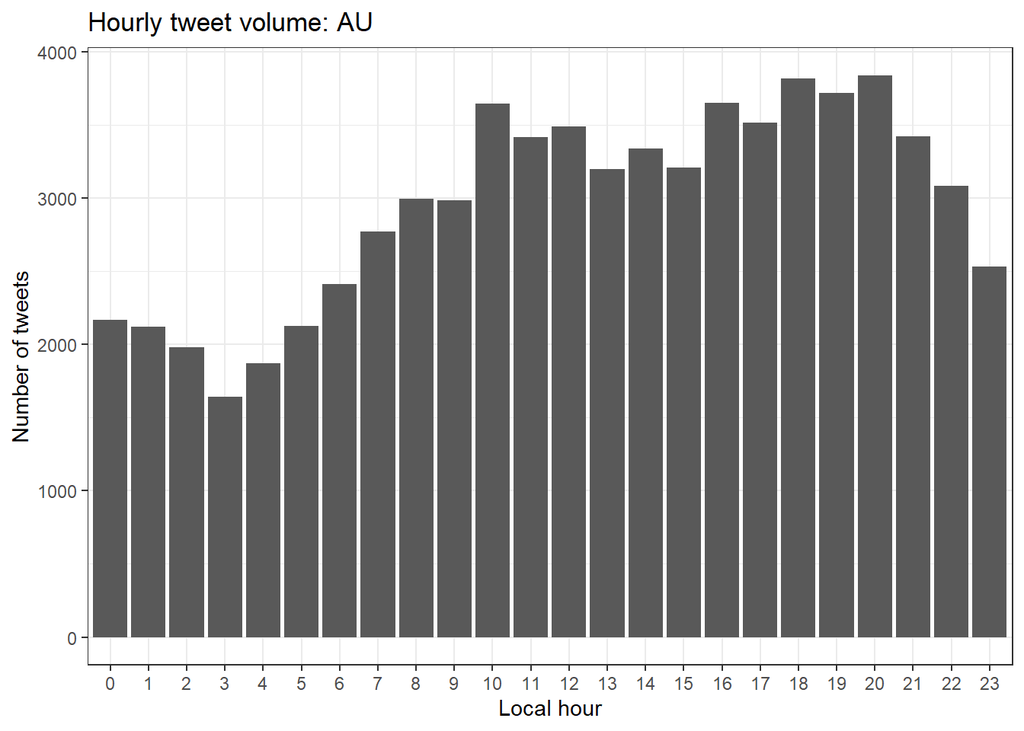

```r
# Helper: plot hourly tweet volume for a given region
plot_hourly <- function(data, region) {
  data |>
    filter(code == region) |>
    group_by(time) |>
    summarise(freq = n(), .groups = "drop") |>
    ggplot(aes(x = time, y = freq)) +
    geom_bar(stat = "identity") +
    labs(title = paste("Hourly tweet volume:", toupper(region)),
         x = "Local hour", y = "Number of tweets") +
    theme_bw()
}

# save data
saveRDS(bdat, here::here("tables", "bdat,rda"))

# plot
plot_hourly(bdat, "au")
```

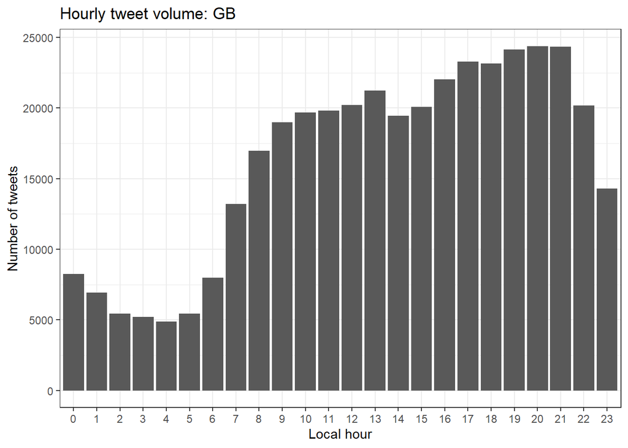

```r
plot_hourly(bdat, "gb")
```

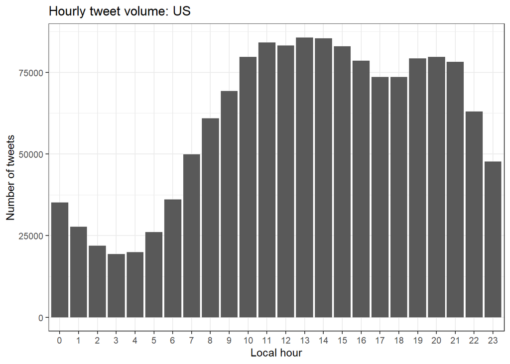

```r
plot_hourly(bdat, "us")
```

## Helper function: compute phi-coefficients for discrete grouping variables

This function computes the phi-coefficient for each level of a grouping variable (e.g. time of day, topic) within each region. Phi measures the strength of association between the grouping level and vulgarity, with sign indicating over- (+) or under- (-) representation relative to chance.

```r
compute_phi <- function(data, group_var) {
  data |>
    group_by(code, {{ group_var }}) |>
    summarise(
      tweets = n(),
      vulgar = sum(vulgar == "1"),
      .groups = "drop"
    ) |>
    group_by(code) |>
    mutate(
      totaltweets = sum(tweets),
      totalvulgar = sum(vulgar)
    ) |>
    ungroup() |>
    mutate(
      O11    = vulgar,
      O12    = totalvulgar - O11,
      O21    = tweets - O11,
      O22    = totaltweets - O11 - O12 - O21,
      R1     = totalvulgar,
      C1     = tweets,
      O11exp = C1 * R1 / totaltweets,
      O11x2  = (O11 - O11exp)^2 / O11exp,
      phi    = sqrt(O11x2 / totaltweets),
      phi    = ifelse(O11 > O11exp, phi, -phi)
    )
}
```

## Figure 3: Vulgarity by time of day

Phi-coefficients per hour-of-day, faceted by region. Red bars indicate hours when vulgarity is over-represented; blue bars indicate under-representation.

```r
Fig3dat <- compute_phi(bdat, time)
head(Fig3dat)
```

```
## # A tibble: 6 × 15
##   code  time  tweets vulgar totaltweets totalvulgar   O11   O12   O21   O22
##   <chr> <fct>  <int>  <int>       <int>       <int> <int> <int> <int> <int>
## 1 au    0       2169     84       70937        2956    84  2872  2085 65896
## 2 au    1       2119     81       70937        2956    81  2875  2038 65943
## 3 au    2       1978     87       70937        2956    87  2869  1891 66090
## 4 au    3       1644     77       70937        2956    77  2879  1567 66414
## 5 au    4       1872     64       70937        2956    64  2892  1808 66173
## 6 au    5       2127     69       70937        2956    69  2887  2058 65923
## # ℹ 5 more variables: R1 <int>, C1 <int>, O11exp <dbl>, O11x2 <dbl>, phi <dbl>
```

Generate the publiacation-ready figure.

[figure not shown]

```r
Fig3dat |>
  mutate(code = dplyr::recode(code,
    "us" = "United States",
    "au" = "Australia",
    "gb" = "United Kingdom"
  )) |>
  ggplot(aes(x = time, y = phi, fill = phi)) +
  geom_bar(stat = "identity", color = "gray10") +
  facet_wrap(~code, nrow = 3) +
  theme_bw() +
  scale_fill_gradient2(low = "blue", mid = "white", high = "red", midpoint = 0) +
  scale_x_discrete(
    breaks = levels(Fig3dat$time),
    labels = paste0(levels(Fig3dat$time), ":00")
  ) +
  theme(
    panel.grid.major = element_blank(),
    panel.grid.minor = element_blank(),
    axis.text.x      = element_text(angle = 90),
    legend.position  = "none"
  ) +
  labs(x = "Time of day (local time)", y = "Phi-coefficient")
```

```r
ggsave(here("figures", "Figure 3 - time.png"),
       width = 15, height = 12, units = "cm", dpi = 600)
```

### Spot-check: what is tweeted in Australia at 6–7 pm?

Inspects the content and topical distribution of Australian vulgar tweets in the early evening hours to understand the phi spike visible in Figure 3.

```r
# Sample of tweet text at 6–7 pm AU
bdat |>
  filter(code == "au", vulgar != "0", time %in% c("18", "19")) |>
  select(wordsonly)
```

```
## # A tibble: 368 × 1
##    wordsonly
##    <chr>
##  1 conspiratorial idiot sounds about right ️
##  2 fuck yeah heroes in a half shell
##  3 you just keep on believing that ken it will be your excuse for not giving a …
##  4 for all the renewable tragics who think sth aust now relies totally on wind …
##  5 on the bottom tf like i m gonna let my sauce and cheese fall off the top and…
##  6 those tatcha lashes were cum saliva and piss proof for a good six months tho…
##  7 oooh lmao that ones on me yea i see now how that can happen in that case mig…
##  8 damn bae is your ass a ball of dough cause it looks like it was made to be b…
##  9 for me the really hilarious part is the people laughing an claiming the case…
## 10 it s the north shore knobs for the spot and out in the first week
## # ℹ 358 more rows
```

```r
# Topic distribution for the same time window
bdat |>
  filter(code == "au", vulgar != "0", time %in% c("18", "19")) |>
  group_by(topic) |>
  summarise(freq = n(), .groups = "drop") |>
  arrange(-freq)
```

```
## # A tibble: 33 × 2
##    topic          freq
##    <fct>         <int>
##  1 adult_content    47
##  2 memes            40
##  3 fashion          21
##  4 media            19
##  5 medical          19
##  6 military         18
##  7 employment       17
##  8 activism         15
##  9 food             14
## 10 crime            12
## # ℹ 23 more rows
```